# Walmart

Зарманбетов Ахмед

### Подгрузка пакетов

```r
library(readr)
library(dplyr)
library(tidyr)
library(ggplot2)
library(Metrics)
library(naniar)
```

### Данные

Нам предоставлены исторические данные о продажах 45 магазинов Walmart, расположенных в разных регионах. В каждом магазине есть несколько отделов, и нам поручено прогнозировать продажи в каждом магазине для каждого отдела.

Зачем нам прогнозировать продажи?

- Нельзя привозить в магазин слишком мало товара, потребителям его может не хватить. Мало того, что они не принесут нам денег, так ещё и станут менее лояльными: “Не поедем в этот магазин. Там вечно ничего нет. Погнали лучше в Магнолию сходим. Там всё есть.”
- Нельзя привозить в магазин слишком много товара. Его нужно хранить. Это лишние расходы. Более того, товар может протухнуть. Придётся его списывать. Это тоже довольно неприятно.

```r
walmart <- read_csv('data/walmart.csv')
```

Нам доступны следующие переменные:

- `Weekly_Sales` – объём продаж в данную неделю в данном отделе
- `Store` – номер магазина;
- `Type` – тип магазина;
- `Size` – размер магазина;
- `Dept` – номер отдела;
- `Date` – дата;
- `IsHoliday` – является ли неделя праздничной;
- `Temperature` – средняя температура в регионе в градусах по Фаренгейту;
- `Fuel_Price` – стоимость топлива в регионе;
- `MarkDown1-5` – данные, связанные с рекламными уценками, которые запускает Walmart. Данные уценки доступны только после ноября 2011 года и доступны не для всех магазинов. Данные анонимизированы. Непонятно на какие именно товары производилась уценка и в каких количествах. Компании часто анонимизируют данные, когда выкладывают их в открытый доступ.
- `CPI` – индекс потребительских цен;
- `Unemployment` – уровень безработицы.
- `next_Weekly_Sales` – объём продаж в следующую неделю в данном отделе (target)

```r
glimpse(walmart)
```

```
## Observations: 418,239
## Variables: 17
## $ Store             <dbl> 1, 1, 1, 1, 1, 1, 1, 1, 1, 1, 1, 1, 1, 1, 1, 1…
## $ Date              <date> 2010-02-05, 2010-02-12, 2010-02-19, 2010-02-2…
## $ Dept              <dbl> 1, 1, 1, 1, 1, 1, 1, 1, 1, 1, 1, 1, 1, 1, 1, 1…
## $ Weekly_Sales      <dbl> 24924.50, 46039.49, 41595.55, 19403.54, 21827.…
## $ IsHoliday         <lgl> FALSE, TRUE, FALSE, FALSE, FALSE, FALSE, FALSE…
## $ Type              <chr> "A", "A", "A", "A", "A", "A", "A", "A", "A", "…
## $ Size              <dbl> 151315, 151315, 151315, 151315, 151315, 151315…
## $ Temperature       <dbl> 42.31, 38.51, 39.93, 46.63, 46.50, 57.79, 54.5…
## $ Fuel_Price        <dbl> 2.572, 2.548, 2.514, 2.561, 2.625, 2.667, 2.72…
## $ MarkDown1         <dbl> NA, NA, NA, NA, NA, NA, NA, NA, NA, NA, NA, NA…
## $ MarkDown2         <dbl> NA, NA, NA, NA, NA, NA, NA, NA, NA, NA, NA, NA…
## $ MarkDown3         <dbl> NA, NA, NA, NA, NA, NA, NA, NA, NA, NA, NA, NA…
## $ MarkDown4         <dbl> NA, NA, NA, NA, NA, NA, NA, NA, NA, NA, NA, NA…
## $ MarkDown5         <dbl> NA, NA, NA, NA, NA, NA, NA, NA, NA, NA, NA, NA…
## $ CPI               <dbl> 211.0964, 211.2422, 211.2891, 211.3196, 211.35…
## $ Unemployment      <dbl> 8.106, 8.106, 8.106, 8.106, 8.106, 8.106, 8.10…
## $ next_Weekly_Sales <dbl> 46039.49, 41595.55, 19403.54, 21827.90, 21043.…
```

### Изучение данных

#### Пропущенные значения

Давайте сначала разберемся с пропущенными значениями. Набор данных достаточно большой, поэтому не будет его рисовать. Посмотрим на статистики.

```r
miss_var_summary(walmart)
```

```
## # A tibble: 17 x 3
##    variable          n_miss pct_miss
##    <chr>              <int>    <dbl>
##  1 MarkDown2         310095     74.1
##  2 MarkDown4         285924     68.4
##  3 MarkDown3         283671     67.8
##  4 MarkDown1         270755     64.7
##  5 MarkDown5         270057     64.6
##  6 Store                  0      0
##  7 Date                   0      0
##  8 Dept                   0      0
##  9 Weekly_Sales           0      0
## 10 IsHoliday              0      0
## 11 Type                   0      0
## 12 Size                   0      0
## 13 Temperature            0      0
## 14 Fuel_Price             0      0
## 15 CPI                    0      0
## 16 Unemployment           0      0
## 17 next_Weekly_Sales      0      0
```

Видим, что пропущенные значения есть только в переменных Markdown1 - Markdown5. Их достаточно много, поэтому просто заменить средним нет смысла. Давайте выбросим их из нашего датасета.

```r
walmart <- walmart %>%
  select(-starts_with('MarkDown'))
```

Теперь в нашем наборе данных нет пропущенных значений.

```r
n_miss(walmart)
```

```
## [1] 0
```

#### Временной ряд продаж

Давайте немного изучим наши данные перед тем как строить модель. Построим временной ряд продаж.

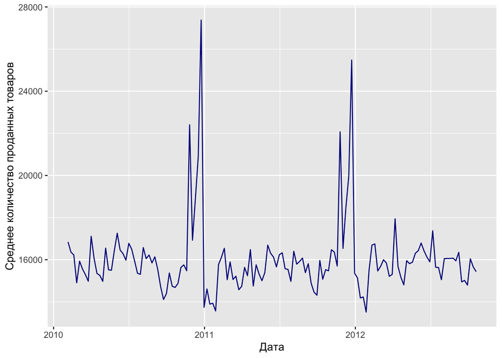

```r
walmart %>%
  group_by(Date) %>%
  summarise(Mean_Weekly_Sales = mean(Weekly_Sales)) %>%
  ggplot(aes(x = Date, y = Mean_Weekly_Sales)) +
    geom_line(color = 'darkblue') +
  labs(x = 'Дата',
       y = 'Среднее количество проданных товаров')
```

#### Статистики

```r
summary(walmart)
```

```
##      Store           Date                 Dept        Weekly_Sales
##  Min.   : 1.0   Min.   :2010-02-05   Min.   : 1.00   Min.   : -4989
##  1st Qu.:11.0   1st Qu.:2010-10-08   1st Qu.:18.00   1st Qu.:  2090
##  Median :22.0   Median :2011-06-17   Median :37.00   Median :  7626
##  Mean   :22.2   Mean   :2011-06-14   Mean   :44.25   Mean   : 16000
##  3rd Qu.:33.0   3rd Qu.:2012-02-17   3rd Qu.:74.00   3rd Qu.: 20227
##  Max.   :45.0   Max.   :2012-10-19   Max.   :99.00   Max.   :693099
##  IsHoliday           Type                Size         Temperature
##  Mode :logical   Length:418239      Min.   : 34875   Min.   : -2.06
##  FALSE:388604    Class :character   1st Qu.: 93638   1st Qu.: 46.66
##  TRUE :29635     Mode  :character   Median :140167   Median : 62.10
##                                     Mean   :136750   Mean   : 60.08
##                                     3rd Qu.:202505   3rd Qu.: 74.36
##                                     Max.   :219622   Max.   :100.14
##    Fuel_Price         CPI         Unemployment    next_Weekly_Sales
##  Min.   :2.472   Min.   :126.1   Min.   : 3.879   Min.   : -4989
##  1st Qu.:2.925   1st Qu.:132.0   1st Qu.: 6.891   1st Qu.:  2090
##  Median :3.445   Median :182.3   Median : 7.866   Median :  7624
##  Mean   :3.358   Mean   :171.2   Mean   : 7.968   Mean   : 15990
##  3rd Qu.:3.735   3rd Qu.:212.4   3rd Qu.: 8.572   3rd Qu.: 20222
##  Max.   :4.468   Max.   :227.2   Max.   :14.313   Max.   :693099
```

Видим, что переменная `Weekly_Sales` и `next_Weekly_Sales` принимают отрицательные значения. Такого быть не должно, так как это выручка магазина. Давайте выкинем такие значения.

```r
walmart <- walmart %>%
  filter(Weekly_Sales > 0) %>%
  filter(next_Weekly_Sales > 0)
```

### Строим модели

Перед тем как строить модели давайте разделим наш датасет на train и test. Так как данные имеют временную структуру, не будем перемешивать наши данные. Посмотрим за сколько недель у нас есть данных.

```r
walmart$Date %>% unique() %>% length()
```

```
## [1] 142
```

Видим, что у нас есть 142 недели в нашем распоряжении. Давайте возьмем первые 110 недель на обучение, а 32 оставшиеся на тестирование.

```r
weeks <- walmart$Date %>% unique() %>% sort()
weeks[110]
```

```
## [1] "2012-03-09"
```

В трейн у нас попадут недели до 2012-03-09, а тест после этой недели, включая эту самую неделю.

```r
train <- walmart %>%
  filter(Date < "2012-03-09")

test <- walmart %>%
  filter(Date >= "2012-03-09")
```

Давайте построим сначала некоторые простые модели. Их результат мы можем взять за базовый (**baseline**).

### 1. Среднее значение по всем отделам всех магазинов

Возьмем константный алгоритм, который будет всегда предсказывать значение равное среднему значению по всем отделам всех магазинов.

```r
train_1 <- train
test_1 <- test

MEAN <- mean(train_1$Weekly_Sales)

train_1$predict1 <- MEAN
test_1$predict1 <- MEAN
```

Подсчитаем чему равно MAPE и MAE.

```r
mae(train_1$next_Weekly_Sales, train_1$predict1)
```

```
## [1] 15228.08
```

```r
mae(test_1$next_Weekly_Sales, test_1$predict1)
```

```
## [1] 15134.17
```

```r
mape(train_1$next_Weekly_Sales, train_1$predict1)
```

```
## [1] 211.0388
```

```r
mape(test_1$next_Weekly_Sales, test_1$predict1)
```

```
## [1] 848.3803
```

Видим большое значение MAPE. Скорее всего MAE тоже большое. Давайте посмотрим на среднее значение нашего таргета.

```r
mean(train_1$next_Weekly_Sales)
```

```
## [1] 16118.9
```

Видим, что MAE и правда большое.

### 2. Среднее значение для каждого отдела в каждом магазине

Магазины и отделы в них бывают разные. Попробуем находить среднее в каждом отделе для каждого магазина.

```r
MEAN_by_Store_Dept <- train %>%
  group_by(Store, Dept) %>%
  summarise(predict2 = mean(Weekly_Sales))

train_1 <- train_1 %>%
  left_join(MEAN_by_Store_Dept, by = c('Store', 'Dept'))

test_1 <- test_1 %>%
  left_join(MEAN_by_Store_Dept, by = c('Store', 'Dept'))
```

Появляются NA, потому что появились новые отделы в магазинах. Пусть если у нас нет прогноза, то мы возьмем прогноз из прошлой модели.

```r
test_1 <- test_1 %>%
  mutate(predict2 = ifelse(is.na(predict2), predict1, predict2))

mae(train_1$next_Weekly_Sales, train_1$predict2)
```

```
## [1] 2781.925
```

```r
mae(test_1$next_Weekly_Sales, test_1$predict2)
```

```
## [1] 2606.157
```

```r
mape(train_1$next_Weekly_Sales, train_1$predict2)
```

```
## [1] 36.15821
```

```r
mape(test_1$next_Weekly_Sales, test_1$predict2)
```

```
## [1] 107.8383
```

Уже получается лучше.

### 3. Значение предыдущей недели

Очень хорошим baseline’ом является следующая простая модель. Давайте привозить на следующую неделю столько товара, сколько мы продали на этой неделе.

```r
train_1$predict3 <- train_1$Weekly_Sales
test_1$predict3 <- test_1$Weekly_Sales

mae(train_1$next_Weekly_Sales, train_1$predict3)
```

```
## [1] 2254.023
```

```r
mae(test_1$next_Weekly_Sales, test_1$predict3)
```

```
## [1] 1648.434
```

```r
mape(train_1$next_Weekly_Sales, train_1$predict3)
```

```
## [1] 1.176847
```

```r
mape(test_1$next_Weekly_Sales, test_1$predict3)
```

```
## [1] 2.129825
```

Мы получили достаточно хорошие результаты. Давайте ориентироваться на них.

### 4. Обычная линейная регрессия

Давайте попробуем построить следующую очень простую регрессию:

$$next_Weekly_Sales = w_0 + w_1 Weekly_Sales$$
.

Она похожа на то, что мы делали ранее.

```r
train_2 <- train
test_2 <- test

model4 <- lm(next_Weekly_Sales ~ Weekly_Sales , data = train_2)

train_2$predict4 <- predict(model4, train_2)
test_2$predict4 <- predict(model4, test_2)

mae(train_2$next_Weekly_Sales, train_2$predict4)
```

```
## [1] 2523.658
```

```r
mae(test_2$next_Weekly_Sales, test_2$predict4)
```

```
## [1] 1941.544
```

```r
mape(train_2$next_Weekly_Sales, train_2$predict4)
```

```
## [1] 13.88451
```

```r
mape(test_2$next_Weekly_Sales, test_2$predict4)
```

```
## [1] 53.67912
```

Результаты получились не такими хорошими как было раньше. Давайте попробуем нарисовать график рессеяния и понять почему так вышло.

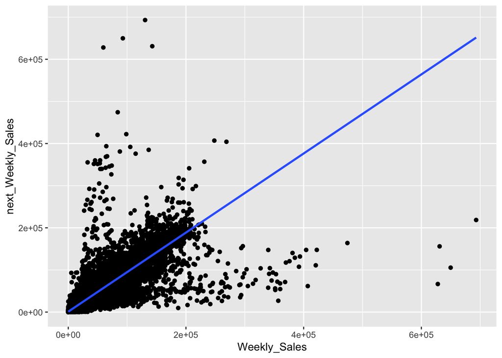

```r
train_2 %>%
  ggplot(aes(Weekly_Sales, next_Weekly_Sales)) +
    geom_point() +
    geom_smooth(method = 'lm')
```

Видно, что облако вытянуто неоднозначно. Есть большие магазины, а есть маленькие. В такой модели мы совсем не учитываем это и мешаем все в одну кучу.

### 5. Линейная регрессия с магазинами и отделами

Попробуем добавить в регрессию номер магазина и номер отдела. Оставлять переменные такими какие они есть не очень корректно, так как мы говорили, что Label Encoding работает не очень хорошо. Давайте закодируем наши магазины и отделы с помощью One Hot Encoding.

```r
# install.packages("fastDummies")
library(fastDummies)

walmart2 <- walmart %>%
  select(Date, Store, Dept, Weekly_Sales, next_Weekly_Sales)

walmart2 <- dummy_cols(walmart2, select_columns = c('Store', 'Dept'),
                remove_first_dummy = T)

train_3 <- walmart2 %>%
  filter(Date < "2012-03-09")

test_3 <- walmart2 %>%
  filter(Date >= "2012-03-09")
```

Обучим модель.

```r
model5 <- lm(next_Weekly_Sales ~ . - 1, data = train_3)

train_3$predict <- predict(model5, train_3)
test_3$predict <- predict(model5, test_3)

mae(train_3$next_Weekly_Sales, train_3$predict)
```

```
## [1] 2726.129
```

```r
mae(test_3$next_Weekly_Sales, test_3$predict)
```

```
## [1] 2186.507
```

```r
mape(train_3$next_Weekly_Sales, train_3$predict)
```

```
## [1] 17.34136
```

```r
mape(test_3$next_Weekly_Sales, test_3$predict)
```

```
## [1] 55.55517
```

### 6. Логарифм таргета

Линейные модели любят, когда таргет да и вообще все переменнын имели нормальное распределение.

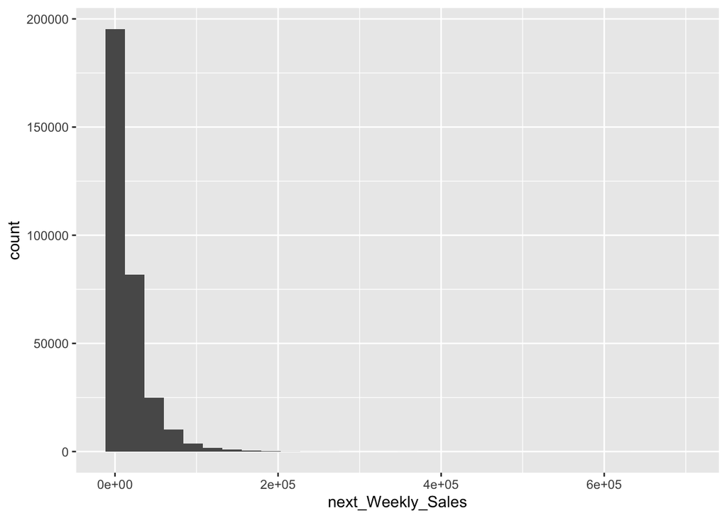

```r
ggplot(train, aes(next_Weekly_Sales)) +
  geom_histogram()
```

Один из легких способов получить нормальное распределение это взять логарифм.

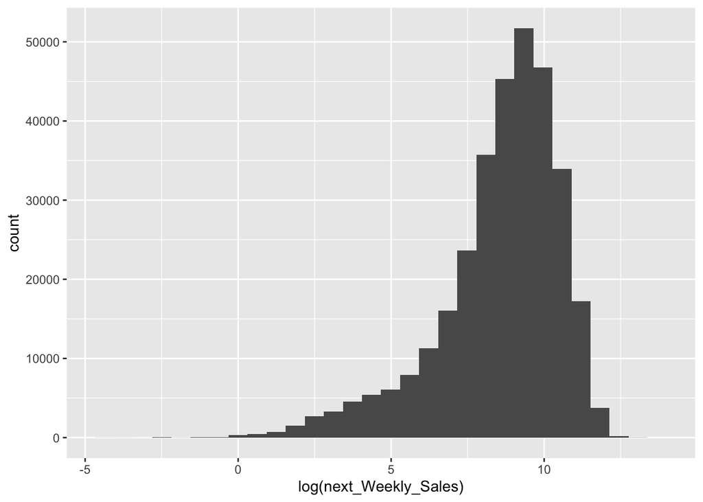

```r
ggplot(train, aes(log(next_Weekly_Sales))) +
  geom_histogram()
```

Попробуем обучить модель с логарифмом таргета. При прогнозе не забываем возращать значения обратно с помощью экспоненты.

```r
train_3 <- walmart2 %>%
  filter(Date < "2012-03-09") %>%
  mutate(next_Weekly_Sales = log(next_Weekly_Sales),
         Weekly_Sales = log(Weekly_Sales)) %>%
  select(-Date, Store, Dept)

test_3 <- walmart2 %>%
  filter(Date >= "2012-03-09") %>%
  mutate(next_Weekly_Sales = log(next_Weekly_Sales),
         Weekly_Sales = log(Weekly_Sales)) %>%
  select(-Date, Store, Dept)

model5 <- lm(next_Weekly_Sales ~ . - 1, data = train_3)

train_3$predict <- exp(predict(model5, train_3))
test_3$predict <- exp(predict(model5, test_3))

mae(exp(train_3$next_Weekly_Sales), train_3$predict)
```

```
## [1] 2304.386
```

```r
mae(exp(test_3$next_Weekly_Sales), test_3$predict)
```

```
## [1] 1741.404
```

```r
mape(exp(train_3$next_Weekly_Sales), train_3$predict)
```

```
## [1] 1.221557
```

```r
mape(exp(test_3$next_Weekly_Sales), test_3$predict)
```

```
## [1] 2.329645
```

### 7. Добавляем остальные признаки

```r
walmart3 <- walmart

walmart3 <- dummy_cols(walmart3, select_columns = c('Store', 'Dept'),
                remove_first_dummy = T)

train_4 <- walmart3 %>%
  filter(Date < "2012-03-09") %>%
  mutate(next_Weekly_Sales = log(next_Weekly_Sales),
         Weekly_Sales = log(Weekly_Sales)) %>%
  select(-Date, Store, Dept)

test_4 <- walmart3 %>%
  filter(Date >= "2012-03-09") %>%
  mutate(next_Weekly_Sales = log(next_Weekly_Sales),
         Weekly_Sales = log(Weekly_Sales)) %>%
  select(-Date, Store, Dept)

model6 <- lm(next_Weekly_Sales ~ . - 1, data = train_4)

train_4$predict <- exp(predict(model6, train_4))
test_4$predict <- exp(predict(model6, test_4))

mae(exp(train_4$next_Weekly_Sales), train_4$predict)
```

```
## [1] 2298.427
```

```r
mae(exp(test_4$next_Weekly_Sales), test_4$predict)
```

```
## [1] 1733.385
```

```r
mape(exp(train_4$next_Weekly_Sales), train_4$predict)
```

```
## [1] 1.22473
```

```r
mape(exp(test_4$next_Weekly_Sales), test_4$predict)
```

```
## [1] 2.342098
```

### 8. Catboost

```r
library(catboost)
library(lubridate)

walmart <- walmart %>%
  arrange(Date) %>%
  group_by(Store, Dept) %>%
  mutate(leadIsHoliday = lead(IsHoliday)) %>%
  ungroup()

train <- walmart %>%
  filter(Date < "2012-03-09")

test <- walmart %>%
  filter(Date >= "2012-03-09")

train_X <- train %>%
  mutate(Month = month(Date)) %>%
  select(-next_Weekly_Sales, Date) %>%
  mutate(Weekly_Sales = log(Weekly_Sales))
train_y <- log(train$next_Weekly_Sales)

test_X <- test %>%
  mutate(Month = month(Date)) %>%
  select(-next_Weekly_Sales, Date) %>%
  mutate(Weekly_Sales = log(Weekly_Sales))
test_y <- log(test$next_Weekly_Sales)

train_X <- train_X %>%
  mutate_at(vars(Store, Date, Dept, IsHoliday, Type, Month, leadIsHoliday), .funs = as.factor)

test_X <- test_X %>%
  mutate_at(vars(Store, Date, Dept, IsHoliday, Type, Month, leadIsHoliday), .funs = as.factor)

train_pool <- catboost.load_pool(data = train_X, label = train_y)
test_pool <- catboost.load_pool(data = test_X, label = test_y)

model <- catboost.train(train_pool,
                        test_pool,
                        params = list(loss_function = 'RMSE',
                                      iterations = 600, metric_period=50,
                                      learning_rate=0.01,
                                      depth=8))
```

```
## 0:   learn: 1.9909453    test: 2.0532070 best: 2.0532070 (0) total: 337ms    remaining: 3m 21s
## 50:  learn: 1.2713687    test: 1.3238342 best: 1.3238342 (50)    total: 14.2s    remaining: 2m 33s
## 100: learn: 0.8541468    test: 0.8999612 best: 0.8999612 (100)   total: 28.3s    remaining: 2m 19s
## 150: learn: 0.6276568    test: 0.6673719 best: 0.6673719 (150)   total: 42.8s    remaining: 2m 7s
## 200: learn: 0.5158031    test: 0.5486551 best: 0.5486551 (200)   total: 56.8s    remaining: 1m 52s
## 250: learn: 0.4650387    test: 0.4935382 best: 0.4935382 (250)   total: 1m 10s   remaining: 1m 38s
## 300: learn: 0.4359049    test: 0.4673599 best: 0.4673599 (300)   total: 1m 24s   remaining: 1m 23s
## 350: learn: 0.4164969    test: 0.4535361 best: 0.4535361 (350)   total: 1m 38s   remaining: 1m 10s
## 400: learn: 0.4057734    test: 0.4482470 best: 0.4482470 (400)   total: 1m 53s   remaining: 56.1s
## 450: learn: 0.3984786    test: 0.4458303 best: 0.4458303 (450)   total: 2m 7s    remaining: 42.3s
## 500: learn: 0.3931817    test: 0.4459996 best: 0.4458303 (450)   total: 2m 22s   remaining: 28.2s
## 550: learn: 0.3891969    test: 0.4479011 best: 0.4458303 (450)   total: 2m 37s   remaining: 14s
## 599: learn: 0.3857831    test: 0.4515847 best: 0.4458303 (450)   total: 2m 53s   remaining: 0us
##
## bestTest = 0.4458302936
## bestIteration = 450
##
## Shrink model to first 451 iterations.
```

```r
train$predict_catboost <- exp(catboost.predict(model, train_pool))
test$predict_catboost <- exp(catboost.predict(model, test_pool))

mae(train$next_Weekly_Sales, train$predict_catboost)
```

```
## [1] 2217.949
```

```r
mae(test$next_Weekly_Sales, test$predict_catboost)
```

```
## [1] 2182.995
```

```r
mape(train$next_Weekly_Sales, train$predict_catboost)
```

```
## [1] 0.7167035
```

```r
mape(test$next_Weekly_Sales, test$predict_catboost)
```

```
## [1] 1.870165
```

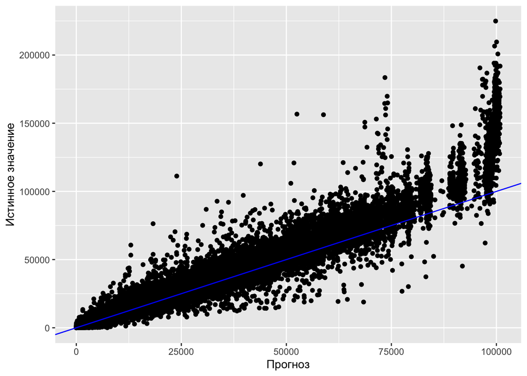

```r
ggplot(test, aes(x = predict_catboost, y = next_Weekly_Sales)) +
  geom_point() +
  geom_abline(color = "blue") +
  xlab('Прогноз') +
  ylab('Истинное значение')
```